# Sintomatología depresiva en personas con Ideación Suicida

Berenice Piceda, Sol Gomez

6/12/2021

# RESUMEN

## 1. Descripción general de la muestra y datos recolectados.

El trabajo se realizará en base a datos sobre sintomatología depresiva a partir de una muestra online de 4909 sujetos. Los datos de los distintos síntomas depresivos han sido obtenidos a partir de la aplicación de la escala Patient Health Questionnaire 9 (PHQ-9), un instrumento estandarizado de autoreporte que indaga sobre nueve síntomas depresivos diferentes. Para ello el instrumento se basa en los criterios diagnóstico para el Trastorno Depresivo Mayor que establece el Manual Diagnóstico y Estadístico de Trastornos Mentales en su quinta edición (DSM-V). La escala contempla la presencia de los siguientes síntomas en las últimas dos semanas: 1) Poco interés; 2) Sensación de depresión; 3) Problemas de sueño; 4) Sensación de cansancio; 5) Poco apetito; 6) Sensación de fracaso; 7) Problemas de concentración; 8) Accionar lento; y 9) Pensamientos suicidas. Los ítems se responden en una escala de Likert desde 1 (nunca) a 5 (casi todos los días).

El principal objetivo de éste trabajo es analizar cómo correlacionan los distíntos síntomas depresivos mencionados (sintomas del 1 (poco interés) al 8 (accionar lento) en función de la variable pensamientos suicidas (que se evalúa a partir del síntoma 9 de la escala PHQ-9). Para esto se seguiran los siguientes pasos de análisis: a) Se aplicarán análisis exploratorios de los datos con el objetivo principal de identificar casos ausentes y atípicos, así como describir la distribución de las puntuaciones y diagramar correlaciones bivariadas; y b) se estimarán modelos de redes denominadas Markov random field o redes no-direccionales (undirected network/undirected graphical model) en dos grupos extremos de participantes distribuidos en base al item 9 de ideación suicida, a los fines de comparar las redes entre los grupos extremos de interés.

## 2. Análisis descriptivos.

El principal objetivo de éste trabajo es analizar el modo en el que se correlacionan los distíntos síntomas depresivos mencionados (sintomas del 1 (poco interés) al 8 (accionar lento)) en función de la variable pensamientos suicidas (que se evalúa a partir del síntoma 9 de la escala PHQ-9), así como la correlación del nivel de depresión general con la edad de los participantes.Estos análisis se realizan en función de la hipótesis principal del trabajo, la cual se basa en que existe una relación entre los síntomas, las variables y la edad.

### -Analisis exploratorio general:

Se analiza la poblacion de manera general en funcion del género y de la edad, contemplando tres grandes grupos o rangos (adolescentes, adultos jóvenes, adultos mayores). Se analiza cómo respondieron dichas categorías a cada una de las preguntas y sus respectivos niveles de respuesta.

### -Matriz de correlación:

Se analiza la correlación entre cada una de las pregruntas respecto de las otras y la correlación entre algunas de las preguntas y la edad.

### -Prueba t:

Separación de los participantes en dos grupos (Ideación suicida (Rta máxima en la escala de Likert a la pregunta 9) y no ideación suicida (Rta = 1 a la pregunta 9) y análisis respecto al resto de las preguntas.

### -Modelo lineal:

Analisis en función del nivel de depresión calculado en base al total de las preguntas y la relación con la edad de los participantes.

### -Estimación de modelos de redes:

se estimarán modelos de redes denominadas Markov random field o redes no-direccionales (undirected network/undirected graphical model) en dos grupos extremos de participantes distribuidos en base al item 9 de ideación suicida, a los fines de comparar las redes entre los grupos extremos de interés. El objetivo de la estimación de modelos de redes es verificar como estas distintas variables correlacionan entre sí, aplicando para esto correlaciones parciales (correlaciones entre pares de ítems controlando por el resto de los ítems o indicadores considerados).

## 3. Estructura de los datos

### 1. Análisis iniciales exploratorios: descriptivos y correlacionales.

Para el caso de los análisis iniciales descriptivos y de correlación con variables sociodemográficas de sexo y edad se trasnformó levemente la tabla: A continuación se describen brevemente los datos y su estructura para este objetivo inicial de análisis (tidy data).

- Cuántas variables tienen? Se tienen cuatro variables, las cuales son : Sexo, Edad, Preguntas (sintomatología, items del PHQ-9) y Respuesta (las opciones de respuestas en escala likert, es decir, con qué frecuencia experimentan los síntomas).
- De qué tipo es cada variable? La variable “Sexo” puede ser int o boolean; “Edad” no tiene rango (int), “Preguntas” es un char y “Respuestas” es un int. Las variables “Preguntas” y “Respuestas” tienen un rango de 1 a 5.
- Cuántas observaciones? Se cuentan con 44181 observaciones, pero éstas se ven reducidas drásticamente al filtrarse los grupos principales, es decir, aquellos que estarían compuestos por las respuestas “1” (no ideación suicida) y “5” (ideación suicida). Es a éstas observaciones que se aplicará el análisis en base a la edad y al sexo.

### 2. Estimación de modelos de redes.

Para este caso no fue pertinente llevar el dataset a un formato tidy similar al aplicado para los análisis iniciales. Esto es así debido a que cada síntoma depresivo se entiende como una variable diferente, que puede estar asociada con las restantes, pero que refiere a un atributo distintivo de la depresión. Más importante aún, el objetivo de la estimación de modelos de redes es verificar como estas distintas variables correlacionan entre sí, y si éstas correlaciones parciales entre ellas presentan alguna diferencia entre dos grupos independientes de participantes (aquellos con alta ideación suicida vs aquellos que no manifestaron ideación suicida). Por todo ello, en este caso se cuenta con 11 variables (edad, sexo, phq-1 al phq-8, y el item 9 del phq que sirve para generar los grupos extremos en esta variable referida a la ideación suicida). Sin embargo, para simplificar la base solo se consideró la variable de ideación suicida con los grupos ya generados (variable grupos extremos en el item 9 del phq, una variable nominal dicotómica, 0 = grupo no ideación suicida y 1 = grupo con ideación suicida) y los síntomas depresivos restantes (ítems 1 al 8 del PHQ-9, variables enteras con rango del 1 al 5). Esta base se denomina “phq.csv” en los análisis correspondientes, y contiene los datos de las 4909 observaciones.

# ANÁLISIS EXPLORATORIO GENERAL

Reconocimiento de la Poblacion.

```r
#carga de datos generales
datos_totales <- read.csv("Datos_Totales.csv", sep = ";", dec = ".", header = TRUE)
```

Conversión de la tabla a tidy. Las preguntas aparecen en una sola columna llamada “Preguntas”, y los valores de respuesta aparecen en una columna asociada llamada “Respuestas”. Tenemos 4 variables finales (sexo, Edad, Preguntas, Respuestas)

```r
datos_totales_Tidy <- datos_totales %>% pivot_longer(c(PocoInteres,SensacionDeDepresion, ProblemasDeSuenio,
                                     SensacionDeCansancio, PocoApetito, SensacionDeFracaso,
                                     ProblemasDeConcentracion, AccionarLento, PensamientosSuicidas),
                                   names_to = "Preguntas", values_to = "Respuestas") %>% drop_na()

#Renombra variable Sexo a "Femenino" y "Masculino"
datos_totales$Sexo <- factor(datos_totales$Sexo, labels=c("Femenino", "Masculino"))
```

Resumen General de los datos originales

```r
datos_totales %>% skim()
```

Data summary

| Name | Piped data |
| --- | --- |
| Number of rows | 4909 |
| Number of columns | 11 |
| _______________________ |  |
| Column type frequency: |  |
| factor | 1 |
| numeric | 10 |
| ________________________ |  |
| Group variables | None |

**Variable type: factor**

| skim_variable | n_missing | complete_rate | ordered | n_unique | top_counts |
| --- | --- | --- | --- | --- | --- |
| Sexo | 0 | 1 | FALSE | 2 | Mas: 3358, Fem: 1551 |

**Variable type: numeric**

| skim_variable | n_missing | complete_rate | mean | sd | p0 | p25 | p50 | p75 | p100 | hist |
| --- | --- | --- | --- | --- | --- | --- | --- | --- | --- | --- |
| Edad | 0 | 1 | 27.14 | 9.86 | 10 | 21 | 23 | 31 | 81 | ▇▃▂▁▁ |
| PocoInteres | 0 | 1 | 3.10 | 1.37 | 1 | 2 | 3 | 4 | 5 | ▆▅▇▆▆ |
| SensacionDeDepresion | 0 | 1 | 3.38 | 1.45 | 1 | 2 | 4 | 5 | 5 | ▃▃▅▅▇ |
| ProblemasDeSuenio | 0 | 1 | 3.59 | 1.48 | 1 | 2 | 4 | 5 | 5 | ▃▂▃▃▇ |
| SensacionDeCansancio | 0 | 1 | 3.87 | 1.22 | 1 | 3 | 4 | 5 | 5 | ▁▂▃▅▇ |
| PocoApetito | 0 | 1 | 3.55 | 1.39 | 1 | 3 | 4 | 5 | 5 | ▃▂▅▅▇ |
| SensacionDeFracaso | 0 | 1 | 3.23 | 1.56 | 1 | 2 | 3 | 5 | 5 | ▆▃▃▅▇ |
| ProblemasDeConcentracion | 0 | 1 | 3.00 | 1.45 | 1 | 2 | 3 | 4 | 5 | ▇▆▇▆▇ |
| AccionarLento | 0 | 1 | 2.64 | 1.38 | 1 | 1 | 3 | 4 | 5 | ▇▅▇▃▃ |
| PensamientosSuicidas | 0 | 1 | 2.32 | 1.56 | 1 | 1 | 2 | 4 | 5 | ▇▂▂▂▃ |

Resumen General de los datos en formato tidy

```r
datos_totales_Tidy$Sexo <- factor(datos_totales_Tidy$Sexo, labels=c("Femenino", "Masculino"))
datos_totales_Tidy %>% skim()
```

Data summary

| Name | Piped data |
| --- | --- |
| Number of rows | 44181 |
| Number of columns | 4 |
| _______________________ |  |
| Column type frequency: |  |
| character | 1 |
| factor | 1 |
| numeric | 2 |
| ________________________ |  |
| Group variables | None |

**Variable type: character**

| skim_variable | n_missing | complete_rate | min | max | empty | n_unique | whitespace |
| --- | --- | --- | --- | --- | --- | --- | --- |
| Preguntas | 0 | 1 | 11 | 24 | 0 | 9 | 0 |

**Variable type: factor**

| skim_variable | n_missing | complete_rate | ordered | n_unique | top_counts |
| --- | --- | --- | --- | --- | --- |
| Sexo | 0 | 1 | FALSE | 2 | Mas: 30222, Fem: 13959 |

**Variable type: numeric**

| skim_variable | n_missing | complete_rate | mean | sd | p0 | p25 | p50 | p75 | p100 | hist |
| --- | --- | --- | --- | --- | --- | --- | --- | --- | --- | --- |
| Edad | 0 | 1 | 27.14 | 9.86 | 10 | 21 | 23 | 31 | 81 | ▇▃▂▁▁ |
| Respuestas | 0 | 1 | 3.19 | 1.50 | 1 | 2 | 3 | 5 | 5 | ▆▃▆▅▇ |

## Grafico de la poblacion general en base a genero y edad

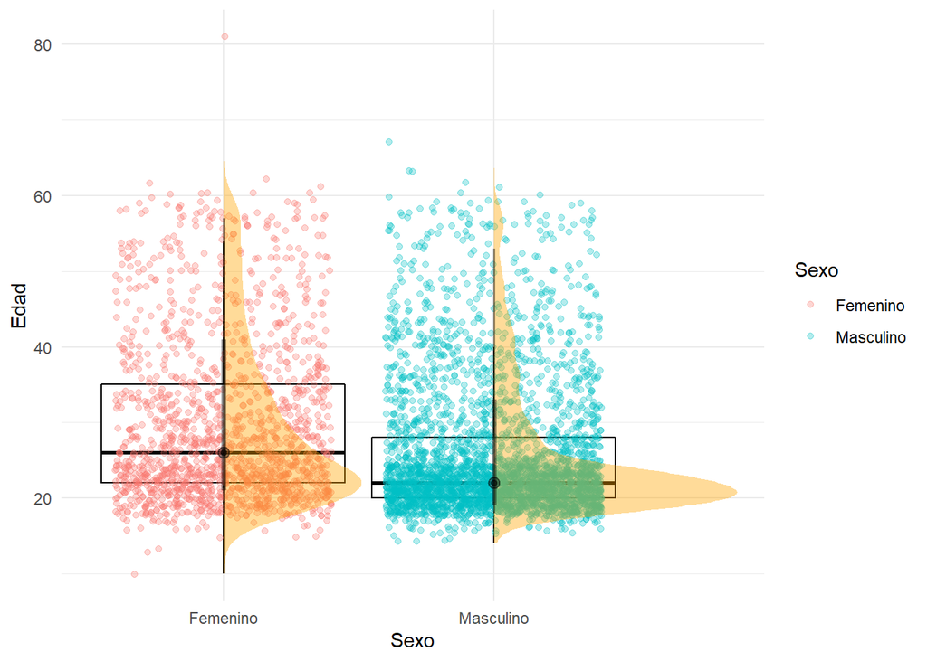

```r
datos_totales_GeneroYEdad <- datos_totales %>%
  ggplot(aes(x = Sexo, y = Edad, color = Sexo)) +
  geom_boxplot(outlier.shape = NA, color = "black", width= 2) +
  geom_jitter(width = 0.4, alpha = 0.3) + theme_minimal() +
  stat_halfeye(color = "black", fill = "orange", alpha = 0.4)
datos_totales_GeneroYEdad
```

La mayoría de la población se corresponde con la Masculina alrededor de 21 años de edad.

## Gráfico de la población general en cantidad por Sexo.

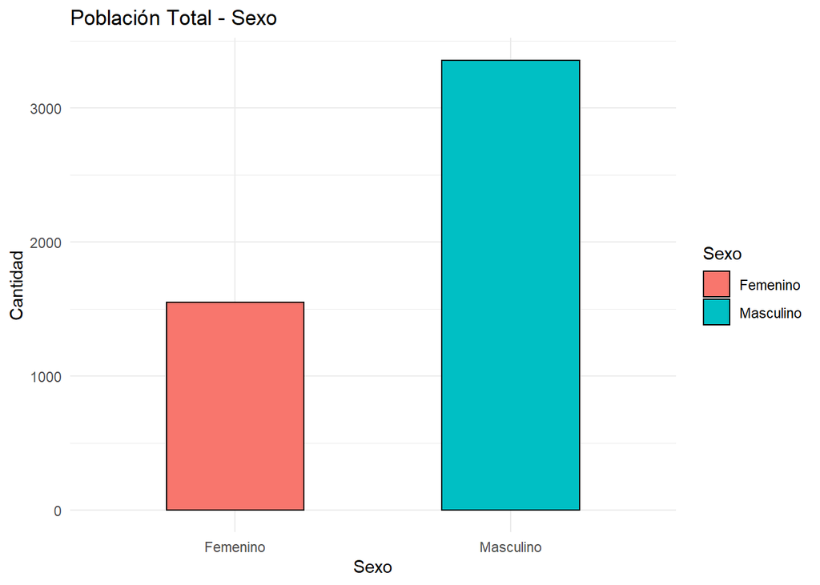

```r
poblacion_por_genero <- datos_totales %>%
  group_by(Sexo) %>%
  summarise(Cantidad = n())
poblacion_por_genero %>% ggplot(aes(x = Sexo, y = Cantidad, fill = Sexo)) +
  geom_col(width = 0.5, color = "black") +
  labs(x = "Sexo",
       y = "Cantidad",
       title = "Población Total - Sexo") +
  theme_minimal()
```

## Grafico General - Respuestas para cada pregunta por cada nivel de respuesta.

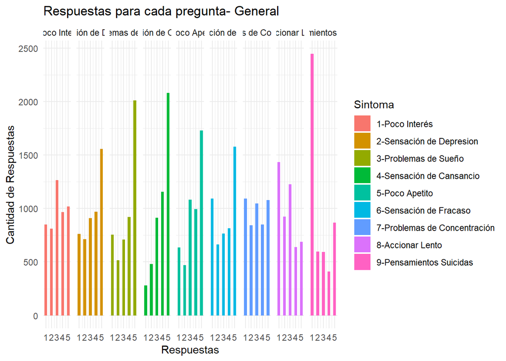

```r
datos_totales_Tidy_Pregunta9 <- datos_totales_Tidy %>%
  arrange(Preguntas) %>% filter(Preguntas == "PensamientosSuicidas") %>%
  group_by(Respuestas) %>%
  summarise(Cantidad_de_rtas = n()) %>%
  mutate(Sintoma = "9-Pensamientos Suicidas")
datos_totales_Tidy_Pregunta8 <- datos_totales_Tidy %>%
  arrange(Preguntas) %>% filter(Preguntas == "AccionarLento") %>%
  group_by(Respuestas) %>%
  summarise(Cantidad_de_rtas = n()) %>%
  mutate(Sintoma = "8-Accionar Lento")
datos_totales_Tidy_Pregunta7 <- datos_totales_Tidy %>%
  arrange(Preguntas) %>% filter(Preguntas == "ProblemasDeConcentracion") %>%
  group_by(Respuestas) %>%
  summarise(Cantidad_de_rtas = n()) %>%
  mutate(Sintoma = "7-Problemas de Concentración")
datos_totales_Tidy_Pregunta6 <- datos_totales_Tidy %>%
  arrange(Preguntas) %>% filter(Preguntas == "SensacionDeFracaso") %>%
  group_by(Respuestas) %>%
  summarise(Cantidad_de_rtas = n()) %>%
  mutate(Sintoma = "6-Sensación de Fracaso")
datos_totales_Tidy_Pregunta5 <- datos_totales_Tidy %>%
  arrange(Preguntas) %>% filter(Preguntas == "PocoApetito") %>%
  group_by(Respuestas) %>%
  summarise(Cantidad_de_rtas = n()) %>%
  mutate(Sintoma = "5-Poco Apetito")
datos_totales_Tidy_Pregunta4 <- datos_totales_Tidy %>%
  arrange(Preguntas) %>% filter(Preguntas == "SensacionDeCansancio") %>%
  group_by(Respuestas) %>%
  summarise(Cantidad_de_rtas = n()) %>%
  mutate(Sintoma = "4-Sensación de Cansancio")
datos_totales_Tidy_Pregunta3 <- datos_totales_Tidy %>%
  arrange(Preguntas) %>% filter(Preguntas == "ProblemasDeSuenio") %>%
  group_by(Respuestas) %>%
  summarise(Cantidad_de_rtas = n()) %>%
  mutate(Sintoma = "3-Problemas de Sueño")
datos_totales_Tidy_Pregunta2 <- datos_totales_Tidy %>%
  arrange(Preguntas) %>% filter(Preguntas == "SensacionDeDepresion") %>%
  group_by(Respuestas) %>%
  summarise(Cantidad_de_rtas = n()) %>%
  mutate(Sintoma = "2-Sensación de Depresion")
datos_totales_Tidy_Pregunta1 <- datos_totales_Tidy %>%
  arrange(Preguntas) %>% filter(Preguntas == "PocoInteres") %>%
  group_by(Respuestas) %>%
  summarise(Cantidad_de_rtas = n()) %>%
  mutate(Sintoma = "1-Poco Interés")
respuestas_por_pregunta <- rbind(datos_totales_Tidy_Pregunta1) %>%
  rbind(datos_totales_Tidy_Pregunta2) %>%
  rbind(datos_totales_Tidy_Pregunta3) %>%
  rbind(datos_totales_Tidy_Pregunta4) %>%
  rbind(datos_totales_Tidy_Pregunta5) %>%
  rbind(datos_totales_Tidy_Pregunta6) %>%
  rbind(datos_totales_Tidy_Pregunta7) %>%
  rbind(datos_totales_Tidy_Pregunta8) %>%
  rbind(datos_totales_Tidy_Pregunta9) %>%
  arrange(Sintoma)
respuestas_por_pregunta %>% ggplot + aes(x = Respuestas, y = Cantidad_de_rtas, fill = Sintoma) +
  geom_col(width = 0.5, position = position_dodge(2)) +
  labs(x = "Respuestas",
       y = "Cantidad de Respuestas",
       title = "Respuestas para cada pregunta- General") +
  theme_minimal() +
  facet_grid(. ~ Sintoma)
```

Se puede observar que, si bien, en la pregunta 9 (Pensamientos suicidas) predomina la respuesta 1. En preguntas correspondientes a otros síntomas (preguntas entre 2 y 6) predomina la respuesta 5.

## Gráficos de la población según Sexo para tres grupos etarios.

### Rangos: 15-20 años, 35-40 años, y 55-60 años.

```r
poblacion_entre15y20 <- datos_totales %>% filter(Edad >= 15 & Edad <= 20)
poblacion_entre35y40 <- datos_totales %>% filter(Edad >= 35 & Edad <= 40)
poblacion_entre55y60 <- datos_totales %>% filter(Edad >= 55 & Edad <= 60)
```

```r
numero_por_genero_entre15y20 <- poblacion_entre15y20 %>%
  group_by(Sexo) %>%
  summarise(Cantidad = n())
entre15y20 <- numero_por_genero_entre15y20 %>% ggplot(aes(x = Sexo, y = Cantidad/9)) +
  geom_col(colour = "black",
           fill = "#1380A1",
           width = 0.5) +
  labs(x = "Sexo",
       y = "",
       title = "Población según género- 15 a 20 años") +
  theme_minimal()

numero_por_genero_entre35y40 <- poblacion_entre35y40 %>%
  group_by(Sexo) %>%
  summarise(Cantidad = n())
entre35y40 <- numero_por_genero_entre35y40 %>% ggplot(aes(x = Sexo, y = Cantidad/9)) +
  geom_col(colour = "black",
           fill = "#1380A1",
           width = 0.5) +
  labs(x = "Sexo",
       y = "",
       title = "Población según género- 35 a 40 años") +
  theme_minimal()

numero_por_genero_entre55y60 <- poblacion_entre55y60 %>%
  group_by(Sexo) %>%
  summarise(Cantidad = n())

entre55y60 <- numero_por_genero_entre55y60 %>% ggplot(aes(x = Sexo, y = Cantidad/9)) +
  geom_col(colour = "black",
           fill = "#1380A1",
           width = 0.5) +
  labs(x = "Sexo",
       y = "",
       title = "Población según género- 55 a 60 años") +
  theme_minimal()
```

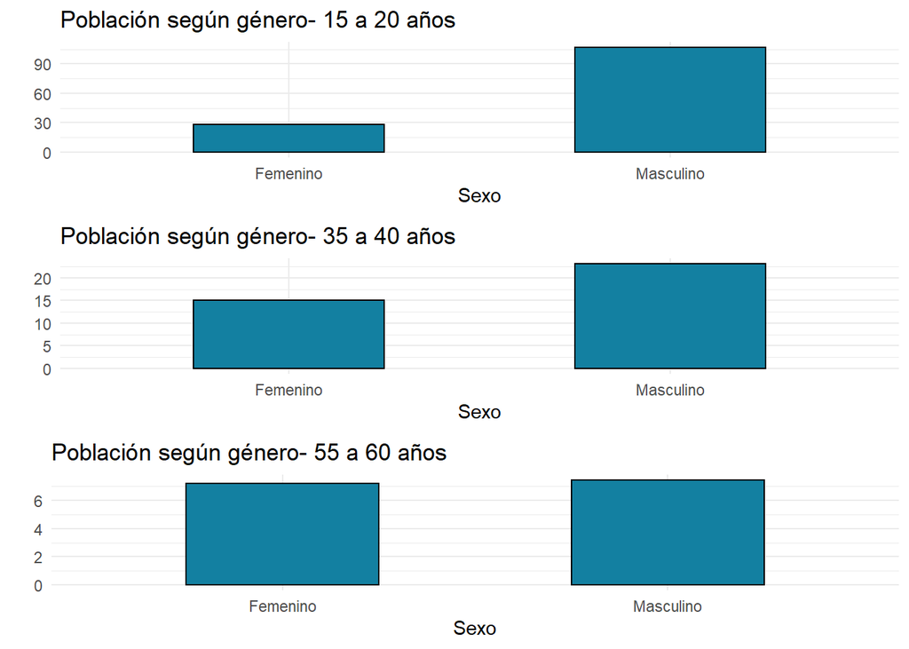

```r
ggpubr::ggarrange(entre15y20, entre35y40, entre55y60, label.y = "Cantidad de Respuestas", nrow = 3)
```

Se observa que a medida que aumenta el rango de edad también se va equilibrando la diferencia de Sexo entre los participantes.

## Nivel de respuestas por cada una de las preguntas. Separación por rangos de edad.

Rangos: 15-20 años, 35-40 años, y 55-60 años.

```r
poblacion_entre15y20 <- datos_totales_Tidy %>% filter(Edad >= 15 & Edad <= 20)
poblacion_entre35y40 <- datos_totales_Tidy %>% filter(Edad >= 35 & Edad <= 40)
poblacion_entre55y60 <- datos_totales_Tidy %>% filter(Edad >= 55 & Edad <= 60)
```

### Rango entre 15 y 20 años.

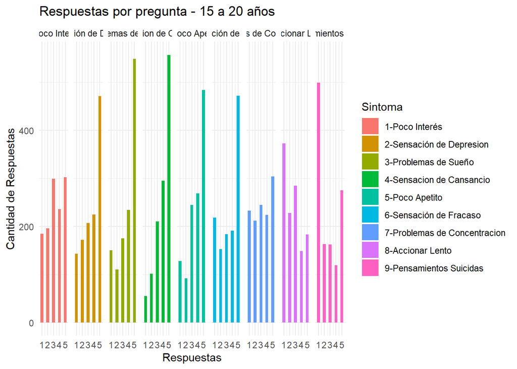

```
(Aclaración: Decidimos dejar este formato de código para el gráfico ya que, a pesar de ser más extenso, nos permite reordenar las variables según el orden de los síntomas, además de renombrarlos para más claridad)
```

```r
poblacion_entre_15y20_Pregunta9 <- poblacion_entre15y20 %>%
  arrange(Preguntas) %>% filter(Preguntas == "PensamientosSuicidas") %>%
  group_by(Respuestas) %>%
  summarise(Cantidad_de_rtas = n()) %>%
  mutate(Sintoma = "9-Pensamientos Suicidas")
poblacion_entre_15y20_Pregunta8 <- poblacion_entre15y20 %>%
  arrange(Preguntas) %>% filter(Preguntas == "AccionarLento") %>%
  group_by(Respuestas) %>%
  summarise(Cantidad_de_rtas = n()) %>%
  mutate(Sintoma = "8-Accionar Lento")
poblacion_entre_15y20_Pregunta7 <- poblacion_entre15y20 %>%
  arrange(Preguntas) %>% filter(Preguntas == "ProblemasDeConcentracion") %>%
  group_by(Respuestas) %>%
  summarise(Cantidad_de_rtas = n()) %>%
  mutate(Sintoma = "7-Problemas de Concentracion")
poblacion_entre_15y20_Pregunta6 <- poblacion_entre15y20 %>%
  arrange(Preguntas) %>% filter(Preguntas == "SensacionDeFracaso") %>%
  group_by(Respuestas) %>%
  summarise(Cantidad_de_rtas = n()) %>%
  mutate(Sintoma = "6-Sensación de Fracaso")
poblacion_entre_15y20_Pregunta5 <- poblacion_entre15y20 %>%
  arrange(Preguntas) %>% filter(Preguntas == "PocoApetito") %>%
  group_by(Respuestas) %>%
  summarise(Cantidad_de_rtas = n()) %>%
  mutate(Sintoma = "5-Poco Apetito")
poblacion_entre_15y20_Pregunta4 <- poblacion_entre15y20 %>%
  arrange(Preguntas) %>% filter(Preguntas == "SensacionDeCansancio") %>%
  group_by(Respuestas) %>%
  summarise(Cantidad_de_rtas = n()) %>%
  mutate(Sintoma = "4-Sensacion de Cansancio")
poblacion_entre_15y20_Pregunta3 <- poblacion_entre15y20 %>%
  arrange(Preguntas) %>% filter(Preguntas == "ProblemasDeSuenio") %>%
  group_by(Respuestas) %>%
  summarise(Cantidad_de_rtas = n()) %>%
  mutate(Sintoma = "3-Problemas de Sueño")
poblacion_entre_15y20_Pregunta2 <- poblacion_entre15y20 %>%
  arrange(Preguntas) %>% filter(Preguntas == "SensacionDeDepresion") %>%
  group_by(Respuestas) %>%
  summarise(Cantidad_de_rtas = n()) %>%
  mutate(Sintoma = "2-Sensación de Depresion")
poblacion_entre_15y20_Pregunta1 <- poblacion_entre15y20 %>%
  arrange(Preguntas) %>% filter(Preguntas == "PocoInteres") %>%
  group_by(Respuestas) %>%
  summarise(Cantidad_de_rtas = n()) %>%
  mutate(Sintoma = "1-Poco Interés")
respuestas_por_pregunta_entre15y20 <- rbind(poblacion_entre_15y20_Pregunta1) %>%
  rbind(poblacion_entre_15y20_Pregunta2) %>%
  rbind(poblacion_entre_15y20_Pregunta3) %>%
  rbind(poblacion_entre_15y20_Pregunta4) %>%
  rbind(poblacion_entre_15y20_Pregunta5) %>%
  rbind(poblacion_entre_15y20_Pregunta6) %>%
  rbind(poblacion_entre_15y20_Pregunta7) %>%
  rbind(poblacion_entre_15y20_Pregunta8) %>%
  rbind(poblacion_entre_15y20_Pregunta9) %>%
  arrange(Sintoma)
respuestas_por_pregunta_entre15y20 %>%
  ggplot(aes(x = Respuestas, y = Cantidad_de_rtas, fill = Sintoma)) +
  geom_col(width = 0.5) +
  labs(x = "Respuestas",
       y = "Cantidad de Respuestas",
       title = "Respuestas por pregunta - 15 a 20 años") +
  theme_minimal() +
  facet_grid(. ~ Sintoma)
```

### Rango entre 35 y 40 años

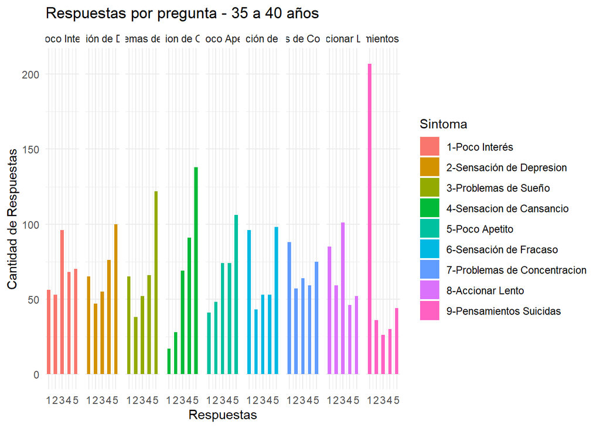

```r
poblacion_entre_35y40_Pregunta9 <- poblacion_entre35y40 %>%
  arrange(Preguntas) %>% filter(Preguntas == "PensamientosSuicidas") %>%
  group_by(Respuestas) %>%
  summarise(Cantidad_de_rtas = n()) %>%
  mutate(Sintoma = "9-Pensamientos Suicidas")
poblacion_entre_35y40_Pregunta8 <- poblacion_entre35y40 %>%
  arrange(Preguntas) %>% filter(Preguntas == "AccionarLento") %>%
  group_by(Respuestas) %>%
  summarise(Cantidad_de_rtas = n()) %>%
  mutate(Sintoma = "8-Accionar Lento")
poblacion_entre_35y40_Pregunta7 <- poblacion_entre35y40 %>%
  arrange(Preguntas) %>% filter(Preguntas == "ProblemasDeConcentracion") %>%
  group_by(Respuestas) %>%
  summarise(Cantidad_de_rtas = n()) %>%
  mutate(Sintoma = "7-Problemas de Concentracion")
poblacion_entre_35y40_Pregunta6 <- poblacion_entre35y40 %>%
  arrange(Preguntas) %>% filter(Preguntas == "SensacionDeFracaso") %>%
  group_by(Respuestas) %>%
  summarise(Cantidad_de_rtas = n()) %>%
  mutate(Sintoma = "6-Sensación de Fracaso")
poblacion_entre_35y40_Pregunta5 <- poblacion_entre35y40 %>%
  arrange(Preguntas) %>% filter(Preguntas == "PocoApetito") %>%
  group_by(Respuestas) %>%
  summarise(Cantidad_de_rtas = n()) %>%
  mutate(Sintoma = "5-Poco Apetito")
poblacion_entre_35y40_Pregunta4 <- poblacion_entre35y40 %>%
  arrange(Preguntas) %>% filter(Preguntas == "SensacionDeCansancio") %>%
  group_by(Respuestas) %>%
  summarise(Cantidad_de_rtas = n()) %>%
  mutate(Sintoma = "4-Sensacion de Cansancio")
poblacion_entre_35y40_Pregunta3 <- poblacion_entre35y40 %>%
  arrange(Preguntas) %>% filter(Preguntas == "ProblemasDeSuenio") %>%
  group_by(Respuestas) %>%
  summarise(Cantidad_de_rtas = n()) %>%
  mutate(Sintoma = "3-Problemas de Sueño")
poblacion_entre_35y40_Pregunta2 <- poblacion_entre35y40 %>%
  arrange(Preguntas) %>% filter(Preguntas == "SensacionDeDepresion") %>%
  group_by(Respuestas) %>%
  summarise(Cantidad_de_rtas = n()) %>%
  mutate(Sintoma = "2-Sensación de Depresion")
poblacion_entre_35y40_Pregunta1 <- poblacion_entre35y40 %>%
  arrange(Preguntas) %>% filter(Preguntas == "PocoInteres") %>%
  group_by(Respuestas) %>%
  summarise(Cantidad_de_rtas = n()) %>%
  mutate(Sintoma = "1-Poco Interés")
respuestas_por_pregunta_entre35y40 <- rbind(poblacion_entre_35y40_Pregunta1) %>%
  rbind(poblacion_entre_35y40_Pregunta2) %>%
  rbind(poblacion_entre_35y40_Pregunta3) %>%
  rbind(poblacion_entre_35y40_Pregunta4) %>%
  rbind(poblacion_entre_35y40_Pregunta5) %>%
  rbind(poblacion_entre_35y40_Pregunta6) %>%
  rbind(poblacion_entre_35y40_Pregunta7) %>%
  rbind(poblacion_entre_35y40_Pregunta8) %>%
  rbind(poblacion_entre_35y40_Pregunta9) %>%
  arrange(Sintoma)
respuestas_por_pregunta_entre35y40 %>%
  ggplot(aes(x = Respuestas, y = Cantidad_de_rtas, fill = Sintoma)) +
  geom_col(width = 0.5) +
  labs(x = "Respuestas",
       y = "Cantidad de Respuestas",
       title = "Respuestas por pregunta - 35 a 40 años") +
  theme_minimal() +
  facet_grid(. ~ Sintoma)
```

### Rango entre 55 y 60 años

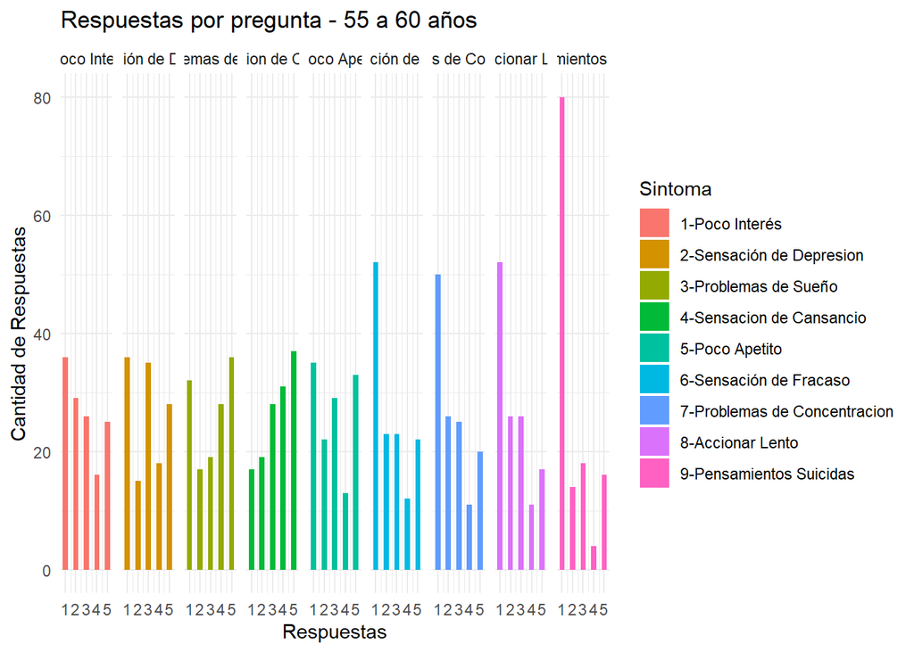

```r
poblacion_entre_55y60_Pregunta9 <- poblacion_entre55y60 %>%
  arrange(Preguntas) %>% filter(Preguntas == "PensamientosSuicidas") %>%
  group_by(Respuestas) %>%
  summarise(Cantidad_de_rtas = n()) %>%
  mutate(Sintoma = "9-Pensamientos Suicidas")
poblacion_entre_55y60_Pregunta8 <- poblacion_entre55y60 %>%
  arrange(Preguntas) %>% filter(Preguntas == "AccionarLento") %>%
  group_by(Respuestas) %>%
  summarise(Cantidad_de_rtas = n()) %>%
  mutate(Sintoma = "8-Accionar Lento")
poblacion_entre_55y60_Pregunta7 <- poblacion_entre55y60 %>%
  arrange(Preguntas) %>% filter(Preguntas == "ProblemasDeConcentracion") %>%
  group_by(Respuestas) %>%
  summarise(Cantidad_de_rtas = n()) %>%
  mutate(Sintoma = "7-Problemas de Concentracion")
poblacion_entre_55y60_Pregunta6 <- poblacion_entre55y60 %>%
  arrange(Preguntas) %>% filter(Preguntas == "SensacionDeFracaso") %>%
  group_by(Respuestas) %>%
  summarise(Cantidad_de_rtas = n()) %>%
  mutate(Sintoma = "6-Sensación de Fracaso")
poblacion_entre_55y60_Pregunta5 <- poblacion_entre55y60 %>%
  arrange(Preguntas) %>% filter(Preguntas == "PocoApetito") %>%
  group_by(Respuestas) %>%
  summarise(Cantidad_de_rtas = n()) %>%
  mutate(Sintoma = "5-Poco Apetito")
poblacion_entre_55y60_Pregunta4 <- poblacion_entre55y60 %>%
  arrange(Preguntas) %>% filter(Preguntas == "SensacionDeCansancio") %>%
  group_by(Respuestas) %>%
  summarise(Cantidad_de_rtas = n()) %>%
  mutate(Sintoma = "4-Sensacion de Cansancio")
poblacion_entre_55y60_Pregunta3 <- poblacion_entre55y60 %>%
  arrange(Preguntas) %>% filter(Preguntas == "ProblemasDeSuenio") %>%
  group_by(Respuestas) %>%
  summarise(Cantidad_de_rtas = n()) %>%
  mutate(Sintoma = "3-Problemas de Sueño")
poblacion_entre_55y60_Pregunta2 <- poblacion_entre55y60 %>%
  arrange(Preguntas) %>% filter(Preguntas == "SensacionDeDepresion") %>%
  group_by(Respuestas) %>%
  summarise(Cantidad_de_rtas = n()) %>%
  mutate(Sintoma = "2-Sensación de Depresion")
poblacion_entre_55y60_Pregunta1 <- poblacion_entre55y60 %>%
  arrange(Preguntas) %>% filter(Preguntas == "PocoInteres") %>%
  group_by(Respuestas) %>%
  summarise(Cantidad_de_rtas = n()) %>%
  mutate(Sintoma = "1-Poco Interés")
respuestas_por_pregunta_entre55y60 <- rbind(poblacion_entre_55y60_Pregunta1) %>%
  rbind(poblacion_entre_55y60_Pregunta2) %>%
  rbind(poblacion_entre_55y60_Pregunta3) %>%
  rbind(poblacion_entre_55y60_Pregunta4) %>%
  rbind(poblacion_entre_55y60_Pregunta5) %>%
  rbind(poblacion_entre_55y60_Pregunta6) %>%
  rbind(poblacion_entre_55y60_Pregunta7) %>%
  rbind(poblacion_entre_55y60_Pregunta8) %>%
  rbind(poblacion_entre_55y60_Pregunta9) %>%
  arrange(Sintoma)
respuestas_por_pregunta_entre55y60 %>%
  ggplot(aes(x = Respuestas, y = Cantidad_de_rtas, fill = Sintoma)) +
  geom_col(width = 0.5) +
  labs(x = "Respuestas",
       y = "Cantidad de Respuestas",
       title = "Respuestas por pregunta - 55 a 60 años") +
  theme_minimal() +
  facet_grid(. ~ Sintoma)
```

Se observa que para el rango de entre 15 y 20 años, hubo mas resupestas máximas (5) para los síntomas del 1 al 7 en comparación con los otros rangos. A medida que aumenta el rango de edad, estos niveles disminuyen o no se destacan tanto respecto de los otros niveles de respuesta.También se observa un mayor número de respuestas máximas para el síntoma de pensamientos suicidas en la población mas jóven.

## Análisis sobre el síntoma Ideación Suicida.

### Comparación entre los niveles de respuestas para el síntoma 9 (Ideación Suicida)

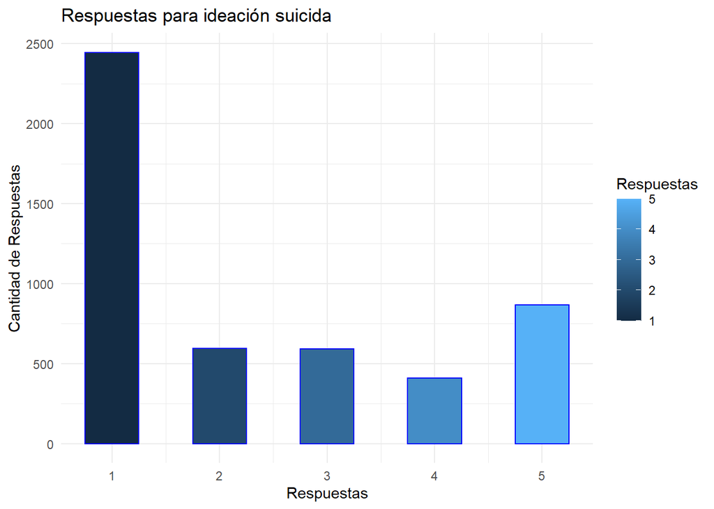

```r
pensamiento_suicida <- datos_totales_Tidy %>%
  filter(Preguntas == "PensamientosSuicidas") %>%
  group_by(Respuestas) %>%
  summarise(Cantidad = n())
pensamiento_suicida %>% ggplot(aes(x = Respuestas, y = Cantidad, fill = Respuestas)) +
  geom_col(width = 0.5, color = "blue") +
  labs(x = "Respuestas",
       y = "Cantidad de Respuestas",
       title = "Respuestas para ideación suicida") +
  theme_minimal()
```

El gráfico muestra que la mayor cantidad de respuestas para el síntoma 9 corresponden a la menor valoración de forma significativa (1, es decir, poco frecuente). Sin embargo, la segunda respuesta más relevante se condice con la de valoración más extrema (5, todos los días), lo cual implicaría la mayor frecuencia.

# MATRIZ DE CORRELACION

## Correlaciones Bivariadas

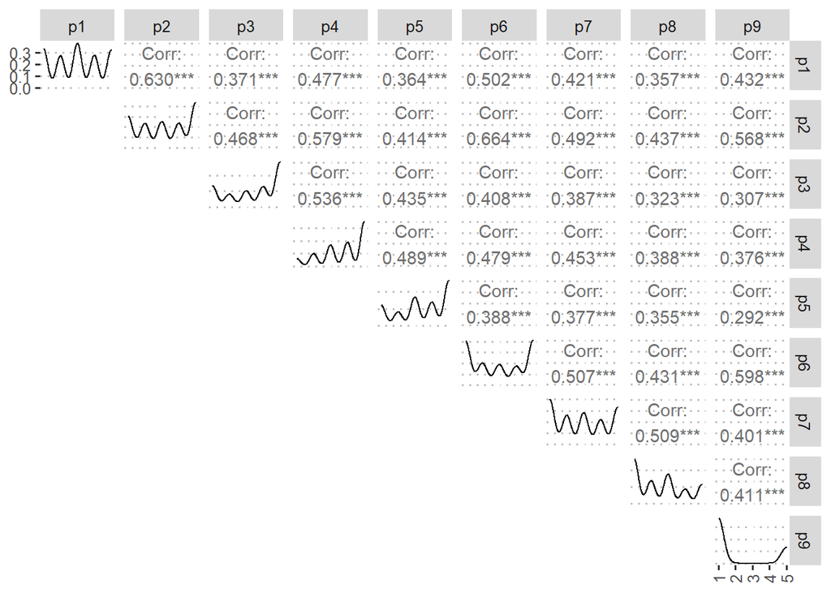

```r
rm(list = ls())
datos_reduccion <- read.csv("Datos_Reduccion.csv", sep = ";", dec = ".", header = TRUE)
datos_reduccion %>%
  drop_na %>%
  select(all_of(c("p1", "p2", "p3", "p4", "p5",
                  "p6","p7", "p8", "p9"))) %>%
  ggpairs(lower = NULL) +
  theme_pubclean() +
  theme(axis.text.x = element_text(angle = 90,
                                   vjust = 0.5,
                                   hjust=1))
```

Se observó una correlación entre los síntomas, destacándose: Sensacion de depresion ->> Sensacion de fracaso ->> Pensamientos suicidas. Respecto al tamaño del efecto o intensidad de las correlaciones, valores de .10, .30, y .50 se consideran pequeños, medios, y largos respectivamente. Según este criterio, la mayor parte de los indicadores de depresión muestran correlaciones de moderada magnitud. Es importante notar que no se observan correlaciones cercanas a 1, lo que pueda estar dando cuenta de multicolinealidad o solapamiento entre indicadores. Todas las correlaciones observadas son estadísticamente significativas (p < .05).

## Matriz de correlacion entre síntomas destacados y la edad

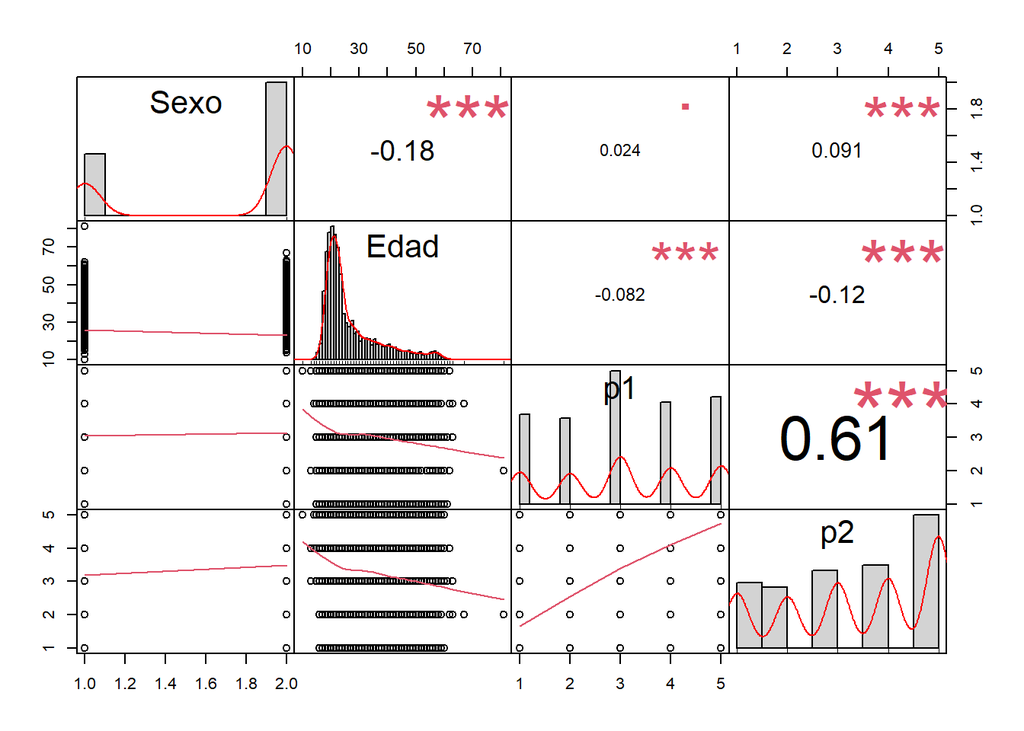

```r
datos_totales_reduccion <- read.csv("Datos_Reduccion.csv", sep = ";", dec = ".", header = TRUE)
matriz2 <- datos_totales_reduccion[,1:4]
cor <- cor(matriz2)
cor2 <- chart.Correlation(matriz2)
```

# PRUEBA T

## Análisis Descriptivo

La columna Suicide-Extrem en los datos representa las respuesta extremas para ideación suicida ya categorizada en 0 = no ideación suicida y 1 = ideación suicida.Se observa una correlación entre los niveles de respuestas máximos a todas las preguntas sintomáticas de la 1 a la 8 en relación con el grupo de ideación suicida. Es decir, los participantes correspondientes al grupo 1 respondieron mayormente con niveles extremos (5) al resto de las preguntas, mientras que en el grupo 0, si bien se destaca mayor presencia en otros síntomas, no se observa una fuerte tendencia a los valores acosiados con la ideación suicida.

### Tabla descriptiva general.

La variable Depresión se calcula en función de la sumatoria de los distintos niveles de respuestas (entre 1 y 5) a los síntomas de 1 a 8 (Excluyendo el factor suicide_extrem). Este factor extremo (respuesta 5) es el que, según la bibliografía, resulta el más estrecho con la ideación suicida, por lo que decidimos hacer especial foco en el mismo.

```r
# Carga y preprocesado de datos
Base <- read.csv("phq.csv", sep = ";", dec = ".", header = TRUE)
Base2 <- Base %>%
 mutate(Depresion = phq1+phq2+phq3+phq4+phq5+phq6+phq7+phq8) %>%
  mutate(Suicide_extrem = as.factor(Suicide_extrem))%>%
   drop_na()

Base2 %>%
group_by(Suicide_extrem) %>%
skim(Depresion)
```

Data summary

| Name | Piped data |
| --- | --- |
| Number of rows | 3312 |
| Number of columns | 10 |
| _______________________ |  |
| Column type frequency: |  |
| numeric | 1 |
| ________________________ |  |
| Group variables | Suicide_extrem |

**Variable type: numeric**

| skim_variable | Suicide_extrem | n_missing | complete_rate | mean | sd | p0 | p25 | p50 | p75 | p100 | hist |
| --- | --- | --- | --- | --- | --- | --- | --- | --- | --- | --- | --- |
| Depresion | 0 | 0 | 1 | 22.31 | 7.39 | 8 | 17 | 22 | 28 | 40 | ▅▆▇▅▂ |
| Depresion | 1 | 0 | 1 | 33.71 | 4.98 | 13 | 31 | 34 | 38 | 40 | ▁▁▂▅▇ |

### Graficos Descriptivos

#### Gráfico comparativo entre grupo 0 y grupo 1 en función del nivel de Depresión.

Gráfico comparativo entre grupo 0 (no ideación suicida) y grupo 1 (ideación suicida) correspondientes al factor suicide_extrem en función del nivel de Depresión medido por la suma de respuestas correspondientes a cada nivel de respuesta (entre 1 y 5). Siendo 8 el valor mínimo posible (la población responde 1 a las 8 preguntas) y 40 el valor máximo posible (la población responde 5 a las 8 preguntas).

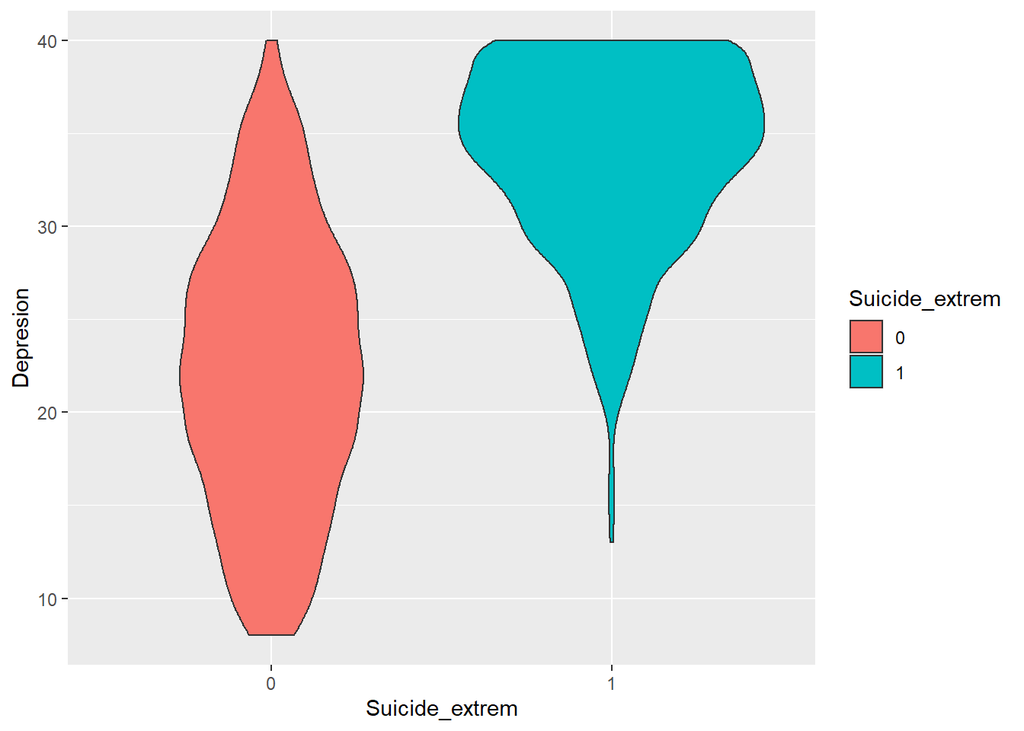

```r
Base2 %>%
    ggplot(aes(x = Suicide_extrem,
               y = Depresion,
               fill= Suicide_extrem)) +
  geom_violin()
```

## Inferenciales - Prueba T

```r
Base2 %>%
group_by(Suicide_extrem)  %>%
summarise(mean(Depresion))
```

```
## # A tibble: 2 x 2
##   Suicide_extrem `mean(Depresion)`
##   <fct>                      <dbl>
## 1 0                           22.3
## 2 1                           33.7
```

```r
t.test(Base2$Depresion~Base2$Suicide_extrem)
```

```
##
##  Welch Two Sample t-test
##
## data:  Base2$Depresion by Base2$Suicide_extrem
## t = -50.491, df = 2256, p-value < 2.2e-16
## alternative hypothesis: true difference in means between group 0 and group 1 is not equal to 0
## 95 percent confidence interval:
##  -11.8357 -10.9507
## sample estimates:
## mean in group 0 mean in group 1
##        22.31235        33.70554
```

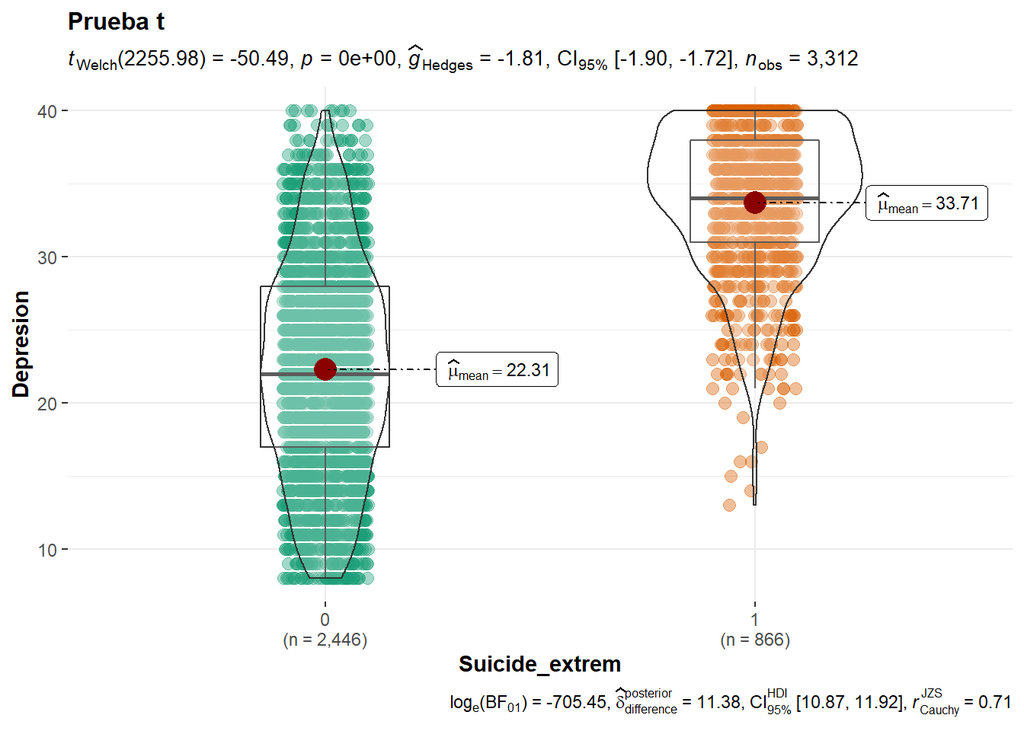

```r
ggbetweenstats(
  data = Base2,
  x = Suicide_extrem,
  y = Depresion,
  title = "Prueba t")
```

Se observa diferencia significativa entre la media de los grupos 0 y 1 para el nivel de depresión calculado en función de los primeros 8 síntomas. Es decir, de acuerdo con los niveles observados, una persona que responde con altos niveles a los síntomas del 1 al 8, tiene mayor probabilidad de tener pensamientos suicidas, tal como se observa en los gráficos descriptivos anteriores. Se aprecian diferencias estadísticamente significativas entre los grupos comparados, siendo mayor el promedio de depresión en el grupo con ideaciones suicidas. Para estas diferencias se obtiene un tamaño del efecto grande.

# MODELO LINEAL

Análisis en función del nivel de depresión y la relación con la edad de los participantes.

## Tabla de resultados para modelo lineal basado en el nivel de depresión y el factor suicide_extrem. Resúmen.

```r
modelo <- lm(Base2$Depresion ~ Base2$Suicide_extrem)
summary(modelo)
```

```
##
## Call:
## lm(formula = Base2$Depresion ~ Base2$Suicide_extrem)
##
## Residuals:
##      Min       1Q   Median       3Q      Max
## -20.7055  -4.7055   0.2945   4.6877  17.6877
##
## Coefficients:
##                       Estimate Std. Error t value Pr(>|t|)
## (Intercept)            22.3123     0.1383  161.31   <2e-16 ***
## Base2$Suicide_extrem1  11.3932     0.2705   42.12   <2e-16 ***
## ---
## Signif. codes:  0 '***' 0.001 '**' 0.01 '*' 0.05 '.' 0.1 ' ' 1
##
## Residual standard error: 6.841 on 3310 degrees of freedom
## Multiple R-squared:  0.3489, Adjusted R-squared:  0.3487
## F-statistic:  1774 on 1 and 3310 DF,  p-value: < 2.2e-16
```

Se observa que los residuos se distribuyen conforme a una distribución normal, ya que la mediana es cercana a 0 (0.2945), y el 1er y 3er cuartil son simétricos. No hay desviaciones notables de media y mediana y hay simetría entre cuartiles, por lo que se cumpliría con los supuestos de los modelos lineales. Por otra parte, el p-value de la prueba de hipótesis del estadístico t indica la probabilidad de obtener un estimado cercano a 0 (<2e-16), por lo que se podría rechazar la hipótesis de nulidad. Además, en los coeficientes encontramos que el error estándar es significativamente bajo.

## Estimadores

```r
broom::tidy(modelo)
```

```
## # A tibble: 2 x 5
##   term                  estimate std.error statistic   p.value
##   <chr>                    <dbl>     <dbl>     <dbl>     <dbl>
## 1 (Intercept)               22.3     0.138     161.  0
## 2 Base2$Suicide_extrem1     11.4     0.271      42.1 8.42e-311
```

## Tabla de resultados para modelo lineal basado en el nivel de depresión y la edad. Resúmen.

```r
Base <- read.csv("Datos_Totales.csv", sep = ";", dec = ".", header = TRUE)
Base_total2 <- Base %>%
  mutate(Depresion = PocoInteres+SensacionDeDepresion+ProblemasDeSuenio+SensacionDeCansancio+PocoApetito+SensacionDeFracaso+ProblemasDeConcentracion+AccionarLento+PensamientosSuicidas) %>%
  drop_na()
modelo <- lm(Base_total2$Depresion ~ Base_total2$Edad)
summary(modelo)
```

```
##
## Call:
## lm(formula = Base_total2$Depresion ~ Base_total2$Edad)
##
## Residuals:
##      Min       1Q   Median       3Q      Max
## -20.7815  -6.6454   0.2185   6.8993  20.8012
##
## Coefficients:
##                  Estimate Std. Error t value Pr(>|t|)
## (Intercept)      32.36866    0.36918   87.68   <2e-16 ***
## Base_total2$Edad -0.13616    0.01279  -10.65   <2e-16 ***
## ---
## Signif. codes:  0 '***' 0.001 '**' 0.01 '*' 0.05 '.' 0.1 ' ' 1
##
## Residual standard error: 8.828 on 4907 degrees of freedom
## Multiple R-squared:  0.02259,    Adjusted R-squared:  0.02239
## F-statistic: 113.4 on 1 and 4907 DF,  p-value: < 2.2e-16
```

Tal y como sucedía con el modelo anterior, se observa que los residuos se distribuyen conforme a una distribución normal, ya que la mediana es cercana a 0 (0.2185), y el 1er y 3er cuartil son simétricos. Por otra parte, el p-value de la prueba de hipótesis del estadístico t indica la probabilidad de obtener un estimado cercano a 0 (una vez más, <2e-16).

## Grafico de modelo lineal en relación a la edad para el nivel de Depresión

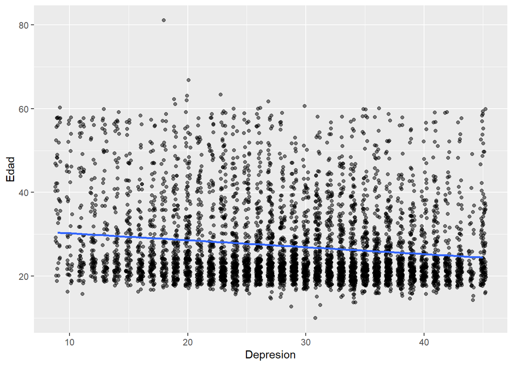

```r
Base_total2 %>%
  ggplot(aes(x = Depresion,
             y = Edad)) +
  geom_jitter(width = 0.23, alpha = 0.5) +
  geom_smooth(se = FALSE,
              method = lm)
```

# ESTIMACION Y COMPARACIÓN DE LOS MODELOS DE REDES

Se estimarán modelos de redes denominadas Markov random field o redes no-direccionales (undirected network/undirected graphical model) en dos grupos extremos de participantes distribuidos en base al item 9 de ideación suicida. Para esto se aplica un modelo de redes denominado Gaussian graphical model (GGM). En GGM cada elemento de la matriz de covarianza inversa corresponde a una conección (edge, aristas) en la red, la cual vincula dos variables (nodes, nodos) si se evidencia una interacción. Las aristas se estandarizan como coeficientes de correlación parcial entre dos variables luego de condicionarlas al resto de las variables del dataset. Con el objetivo de minimizar los errores estándares así como la inestabilidad de los parámetros estimados debido al overfitting (particularmente en muestras pequeñas), es que, en lugar de estimar la GGM directamente invirtiendo la matriz de varianza-covarianza, el modelo se estima utilizando Least Absolute Shrinkage and Selection Operator (LASSO). A los fines de comparar las redes entre los grupos extremos de interés es que se consideran las siguientes medidas de invarianza: invarianza estructural (network structure invariance), invarianza en la fuerza global de las correlaciones (global strength invariance), e invarianza al nivel de las correlaciones parciales entre dos nodos dados (edge invariance). En cada una de estas se aplican pruebas de hipótesis basadas en permutaciones (permutation based hypothesis test) para verificar si se aprecian o no diferencias estadísticamente significativas en cada una de las medidas de invarianza.

## 1. Estimacion de Redes

### Grupo Ideación Suicida

```r
Base <- read.csv("phq.csv", sep = ";", dec = ".", header = TRUE)
suicide <- Base[Base$Suicide_extrem == 1, ]
non_suicide <- Base[Base$Suicide_extrem == 0, ]
data_suicide <- suicide[2:9]
data_nonsuicide <- non_suicide[2:9]
data_suicide <- na.omit(data_suicide)
data_nonsuicide <- na.omit(data_nonsuicide)

Network_suicide <- estimateNetwork(data_suicide,
                                 default = "EBICglasso",
                                 corMethod = "spearman")
```

```
## Estimating Network. Using package::function:
##   - qgraph::EBICglasso for EBIC model selection
##     - using glasso::glasso
```

```r
Network_non_suicide <- estimateNetwork(data_nonsuicide,
                                   default = "EBICglasso",
                                   corMethod = "spearman")
```

```
## Estimating Network. Using package::function:
##   - qgraph::EBICglasso for EBIC model selection
##     - using glasso::glasso
```

```
## Note: Network with lowest lambda selected as best network: assumption of sparsity might be violated.
```

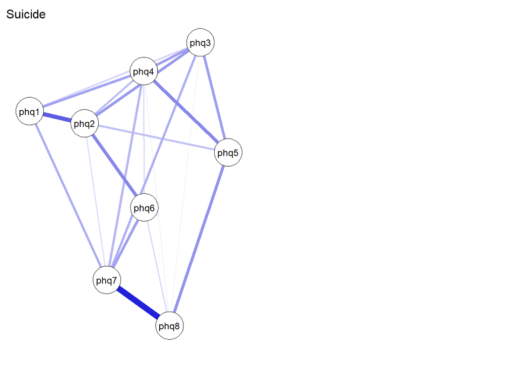

```r
L <- averageLayout(Network_suicide, Network_non_suicide)
Max <- max(abs(c(getWmat(Network_suicide), getWmat(Network_non_suicide))))
layout(t(1:2))
plot(Network_suicide, layout = L, title = "Suicide", maximum = Max)
```

### Grupo No Ideación Suicida

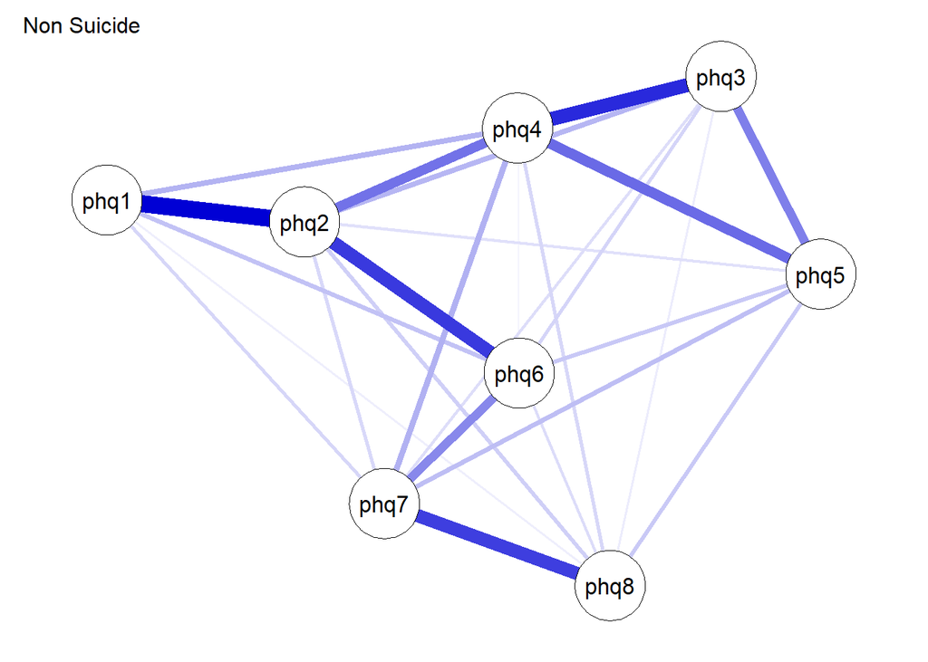

```r
plot(Network_non_suicide, layout = L, title = "Non Suicide", maximum = Max)
```

## 2. Test de Comparación de Redes

```r
set.seed(1)
NCTres <- NCT(data_suicide, data_nonsuicide,
              it=100,
              test.edges = TRUE,
              progressbar= FALSE,
              edges = "all",
              p.adjust.methods = "bonferroni")
summary(NCTres)
```

```
##
##  NETWORK INVARIANCE TEST
##       Test statistic M:  0.1702019
##  p-value 0
##
##  GLOBAL STRENGTH INVARIANCE TEST
##       Global strength per group:  2.487601 3.171567
##  Test statistic S:  0.6839659
##  p-value 0
##
##  EDGE INVARIANCE TEST
##       Edges tested:
##  Test statistic E:  0 0.1683128 0.07690371 0.04806221 0.05725367 0.09366271 0.04144196 0.02943181 0.1683128 0 0.008141929 0.07379801 0.009249531 0.08353979 0.00481754 0.05941067 0.07690371 0.008141929 0 0.1702019 0.04318059 0.05203853 0.08866734 0.01035627 0.04806221 0.07379801 0.1702019 0 0.0787…
##  p-value 0 0.56 1 1 1 0 1 1 1 1 0.84 0.84 1 1 1 1 1 0.84 1 1 1 1 1 1 1 1 1 1
##
##  CENTRALITY INVARIANCE TEST
##       Nodes tested:
##  Centralities tested:
##  Test statistic C:
##  p-value
```

```r
NCTres$einv.pvals[which(NCTres$einv.pvals[,3] < 0.05), ]
```

```
##    Var1 Var2 p-value
## 9  phq1 phq2       0
## 27 phq3 phq4       0
```

A partir de estos análisis se verifica que las redes no son invariantes. Esto último se evidencia en términos de invarianza estructural (network structure invariance), invarianza en la fuerza global de las correlaciones (global strength invariance), e invarianza al nivel de las correlaciones parciales entre dos nodos dados (edge invariance). Sin embargo, y contrario a lo que se esperaba (si bien no se plantearon hipótesis concretas era esperable que en el grupo con ideación suicida los indicadores de depresión presentaran mayor conectividad entre sí en comparación con el grupo sin ideación suicida), se verificó que las correlaciones parciales son más fuertes entre los indicadores de depresión en el grupo sin ideación que en el grupo con ideación suicida.